# Report on the “Ebuy”-data

Stefan Lustfeld and and Nicki Graczyk

July 2019

$~$

# 1 Introduction

Hereby we hand over our analysis of the data that we had received by our customer “Ebuy Inc”. This report consists of several tables and plots, each of them being explained according to their meaning, and therefore should be comprehensible for both data scientists as well as non-specialists.

$~$

## 1.1 Requieries

In order to run this report properly, the **following preconditions** have to be accomplished:

- The folder *“DSP-data”* including all it’s subfolders
- The following databases:
  - *“order.csv”* and it’s column-description *“order_columns.txt”* in *“DSP-data/01-raw-data/orders”*
  - *“clickstream_data.csv”* and it’s column-description *“clickstream_columns.txt”* in *“DSP-data/01-raw-data/clickstream”*
  - *“experimental_results.csv”* in *“DSP-data/01-raw-data/experiment”*
  - Optionally: *“clickstream_data_part_2.csv”* in *“DSP-data/01-raw-data/clickstream”*
- The following R-libraries:
  - *dplyr*
  - *ggplot2*
  - *kableExtra*
  - *knitr*
  - *plyr*
  - *reshape2*
  - *sqldf*
  - *stringr*
  - *tidyr*
  - *tidyverse*
  - *usmap*

This report is not dependend on the particular database-files assigned up to this point, meaning that they may be replaced by more up-to-date or more comprehensive ones. However, the database-files that are applied need to correspond to the delivered column descriptions, and the column names as described in them must not be changed.

$~$

## 1.2 Assumptions

In some parts of this report, it has been necessary to make contentual assumptions. The following example will give an idea of this:

The database classifies the shops goods into the three categories *Men*, *Women* and *Children*. However, there are also *Null*-Values, indicating that the corresponding good has not been allocated to one of these categories. Altough this could have various reasons (categorizing them has been missed, they are unisex-goods and so on), we have summed them up as being in *No Category*.

Any of these assumptions have been specifically marked as such.

$~$

# 2 Data import

This report is based on

Both clickstream-files have then been merged to the file clickstream_data.csv_.

In an automated process, we have removed 54 out of 232 columns from the *order_data.csv*-file due to lack of meaningfulness. For the same reason and in the same manner, we have removed87 out of 215 columns in the *clickstream_data.csv*-file.

We assumed such a lack of meaningfulness whenever a column met one of the following conditions:

- At least 90% values of the column equalled either *NULL*, *?* or *NA*
- More than 97% values of the column were the same (almost always due to *NULL*-values)
- At least 90% values of the column were equal while the second most common value was *NULL*

Taken together, the final dataset consists of * *orders_data.csv* with 3465 rows and 178 columns * *clickstream_data.csv* with 164364 rows and 128 columns

Any further restrictions on these datasets (for example leaving out rows where no gender was set if the respecting analysis referred to gender) have been specifically marked as such.

$~$

# 3 Descriptive statistics

$~$

## 3.1 Tables

### 3.1.1 Customer-based statistics

Table 3.1: *Basic data about customers*

| Gender | Ratio (%) | Average Age (yr) | Std. Dev. Age | Married (%) | Parent (%) |
| --- | --- | --- | --- | --- | --- |
| All | 100 | 38 | 9.668004 | 70.75 | 53.01 |
| Female | 85.81 | 37 | 9.472946 | 73.93 | 56.02 |
| Male | 14.19 | 38 | 10.695889 | 51.52 | 34.85 |

Table 3.1 shows some basic data about the customers. For these results, we have considered $n=$ 945 unique customers.

When distinguishing genders, it is most striking that the very large majority -more than 85%- of the customers is female. Besides, female customers are more likely to be married and to have children than male customers.

$~$

Table 3.2: *Income of customers and it’s possible effect on order amount*

| Minimum income in USD | Ratio (%) | Male (USD) | Female (USD) | Both (USD) | NA |
| --- | --- | --- | --- | --- | --- |
| 0 | 5.23 | 18.26 | 12.25 | 15.255 | 15.255 |
| 15000 | 3.64 | 77.01 | 10.11 | 43.560 | 43.560 |
| 20000 | 8.78 | 9.92 | 7.66 | 8.790 | 8.790 |
| 30000 | 10.27 | 6.35 | 9.49 | 7.920 | 7.920 |
| 40000 | 11.20 | 5.88 | 9.68 | 7.780 | 7.780 |
| 50000 | 25.49 | 11.24 | 10.95 | 11.095 | 11.095 |
| 75000 | 16.15 | 19.52 | 14.38 | 16.950 | 16.950 |
| 100000 | 7.28 | 12.60 | 16.67 | 14.635 | 14.635 |
| 125000 | 11.95 | 20.07 | 21.24 | 20.655 | 20.655 |

In table 3.2, we have analysed the income of customers in order to find out if the shop appears to be more attractive to specific income brackets and if a higher income results in a higher order amount. $n=$ 1071 customers gave evaluable answers to this question.

The results show that generally none of the income brackets are negligble, and that there is no clear pattern that would impose oneself at first sight. However, when disregarding the outlier value of 77.01, it seems that customers with a higher income have a tendency to spend more money.

$~$

Table 3.3: *Usage of coupons and it’s possible effect on order amount*

| Gender | Usage | WITHOUT coupon | WITH coupon |
| --- | --- | --- | --- |
| Overall | 85.24 | 45.14 | 17.54 |
| Male | 79.56 | 43.77 | 19.26 |
| Female | 86.38 | 45.55 | 17.22 |

Table 3.3 reveals the percental usage of coupons by $n=$ 1084 customers. In average, these coupons granted a discount of 10.6USD, which is because the very most of them were tightened to a value of 10 USD.

At the same time it becomes obvious that in average, the invoiced amount of an order where a coupon was used is much lower compared to the one without coupon use.

$~$

### 3.1.2 Product-based statistics

Table 3.4: *Most requested product categories*

| Category | Amount | Ratio |
| --- | --- | --- |
| Women | 2501 | 72.18 |
| Men | 385 | 11.11 |
| No Category | 384 | 11.08 |
| Children | 195 | 5.63 |

In table 3.1 we had already shown that the very large amount of customers is female. Table 3.4 shows that this is conform with the product gender categories: If products that are not allocated to one of the three categories *Male*, *Female* or *Child* (most probably unisex-products) are considered as well, 72.18% of all ordered products belong to the *Female*-sector, and only 16.74% of the sold products are accounted to products for *Men* and *Children*

Table 3.5: *“Top Ten” of the brands offered by the store*

| Brand | Overall | Women | Men | Children |
| --- | --- | --- | --- | --- |
| American Essentials | 680 | 325 | 355 | 0 |
| Ridgeview | 541 | 541 | 0 | 0 |
| HAN | 428 | 428 | 0 | 0 |
| Donna Karan Company | 353 | 353 | 0 | 0 |
| HOSO | 347 | 347 | 0 | 0 |
| Peneco | 292 | 132 | 0 | 160 |
| Paul Lavitt Mills Inc. | 161 | 131 | 30 | 0 |
| Berkshire | 152 | 152 | 0 | 0 |
| ORO | 57 | 57 | 0 | 0 |
| High Point Knitting Inc. | 35 | 0 | 0 | 35 |
| All other brands: | 35 | 35 | 0 | 0 |

$~$

### 3.1.3 Implications

So far, we have shown that a very large majority of customers is female, 38 years old, two out of three of them are married and it is about one half of them who have at least one children. Regarding the most basic product categories of *Women*, *Men*, *Children* and uncategorized products we have seen that the demand of products extends the impression that the shops most targeted audience are women.

We have also shown that the usage of coupons is very common, which generally encourages offering such coupons, but comes along with about half the invoice amount of those orders where no coupon was used.

Further, we have seen that only about 1.15% of all sales related products that were not categorized as part of what we have figured out as the “Top Ten” brands.

From that we conclude that

- If the store had to undergo changes due to a troubled business situation, it should concentrate on what can be figured out as the core competencies by undergoing one of the following steps (increasing intense):
  - Drop brands that are not part of the aforenamed “Top Ten” brands, as they are barely requested. The results suggest the assumption that this would have a very low effect on sells, but it would thin out administrative workload.
  - Drop products that are categorized as for *Children*, as the results show that this is by far the least often requested category. Looking at the data makes it likely that this would have a greater (negative) effect on sells, but on the other hand further reducing business workload.
  - As a most striking step, the shop could limit it’s products to those for *Women*, which is by far the most attractive product category.
- As far as the offering of coupons is concerned, we have seen that this is a good idea. Anyway, we suggest trying not to set a constant discount per coupon, but to leave it percental of the invoice amount. By that, customers might be encouraged to buy more products in order to reach a higher discount.

$~$

## 3.2 Figures

### 3.2.1 Figures regarding customers

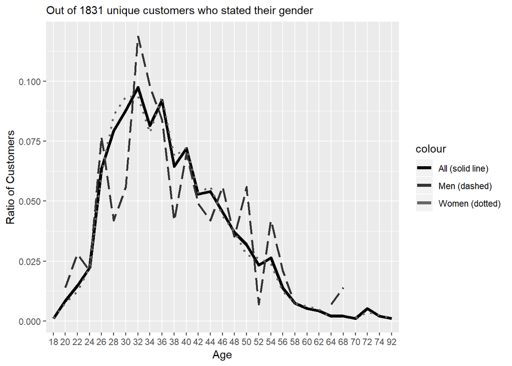

Figure 3.1: Age of customers

$~$

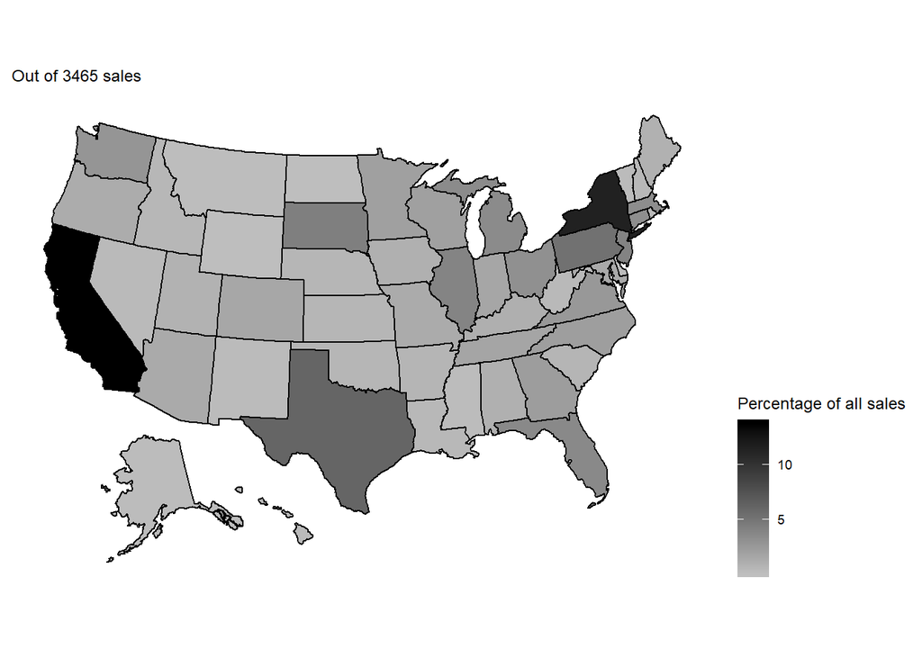

Figure 3.2: Geographical distribution of sales

The map on Figure 3.2 illustrates the origin of customers.

Basically it shows that there are customers from every state, but distinctly increased sales numbers by customers from California and New York, which are less obviously, but still recognizably followed by Texas and Pennsylvania.

$~$

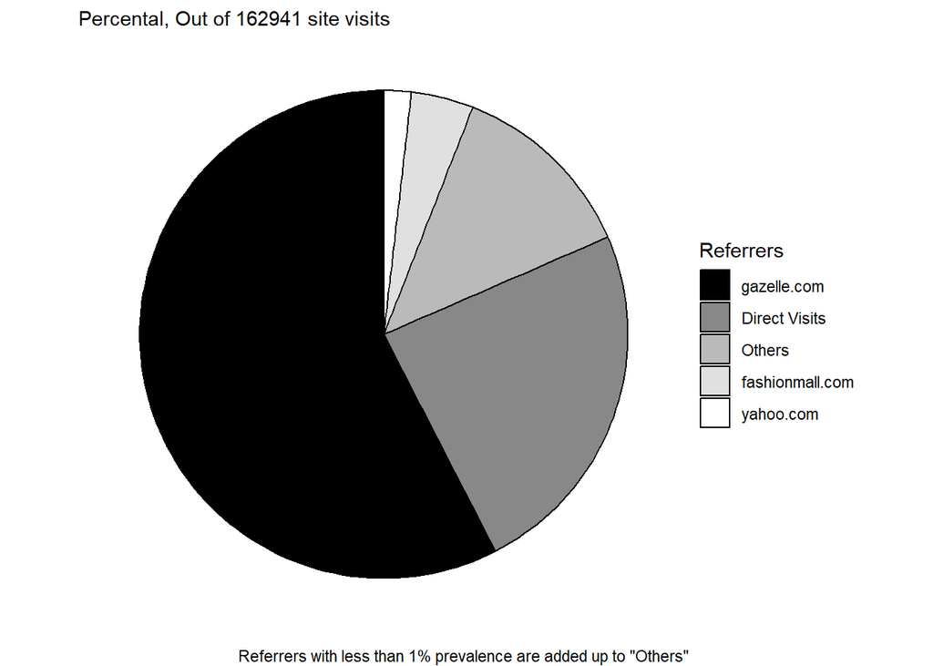

Figure 3.3: Website visit referers

In 3.3 we have analysed how internet users get to the shops webpage. While about one quarter gets to it by directly visiting it (*Direct Visits*, from our point of view this is a hint that they most probably means that they know the shop already), over one half visited the page after being referred by *gazelle.com*. Further, but much less weighty players are *fashionmall.com* and *yahoo.com*, while all others deceeded a value of 1% and are therefore added up to *Others* in our figure.

$~$

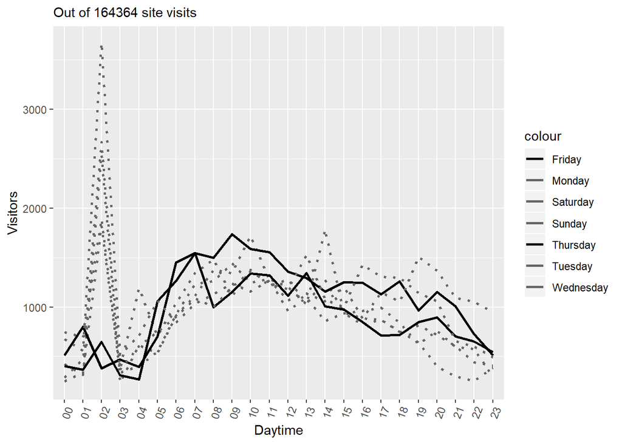

Figure 3.4: Daytime of visits per day of the week

$~$

### 3.2.2 Figures regarding products

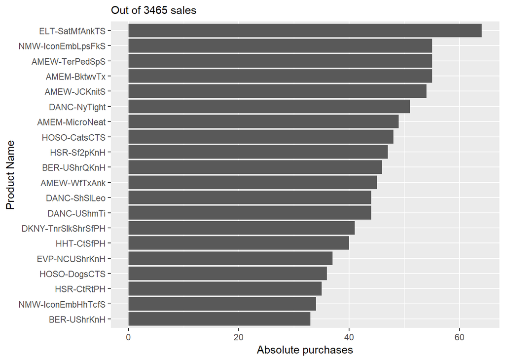

Figure 3.5: Most popular products

Figure 3.5 sums up the twenty best-liked of all offered products.

$~$

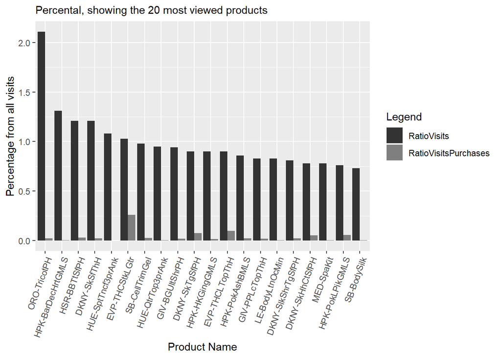

Figure 3.6: Ratio of visits and sells per Product

Generally, there is a large difference in products that are visited and those that are bought, as Figure 3.6 shows. Sorting the twenty most visited products, it evides that many clicks are no guarantee for many purchases. Nevertheless, the results are interesting in two ways:

- The product that is referred to as *“ORO-TricotPH”* has significantly more visits than any other product of the store. We don’t know the background of the product, but it appears to us that there might be some advertising going on - with quite good success, even if the visits do not come along with accordingly many sales.
- The product that is referred to as *“EVP-THCStkLGtr”* is remarkable as well: Unlike any other product, about one quarter of all visits leads to a sale.

Combining these two aspects - deploying the advertising-strategies that lead to many visits as mentioned in the first example with those products that have an above-average ratio of visit and sale might be an idea to increase sales in general.

$~$

# 4 Experiment on Recommender systems

Ebuy has performed an experiment in order to compare three different kinds of recommender systems:

- Ranking-based
- Random-based
- Profit-oriented

The experiments raw-data covered 154 measured points for the three kinds, from which we used 146 entries in order to cut out *NA*-values.

To find out which recommender system comes along with the highest value for the shop, we have ascertained a confidence intervall for each system and for the three most common confidence levels:

- Table 4.1 shows the results for a confidence level of 0.975
- Table 4.2 shows the results for a confidence level of 0.95
- Table 4.3 shows the results for a confidence level of 0.9

Table 4.1: *Value of Recommender systems, confidence level 0,975*

| Recommendation | Lower Bound | Upper Bound | Range |
| --- | --- | --- | --- |
| Ranking based | 17.99824 | 18.92808 | 0.9298373 |
| Random | 17.27038 | 18.46931 | 1.1989298 |
| Profit oriented | 21.56248 | 21.94349 | 0.3810146 |

Table 4.2: *Value of Recommender systems, confidence level 0,95*

| Recommendation | Lower Bound | Upper Bound | Range |
| --- | --- | --- | --- |
| Ranking based | 18.04277 | 18.86661 | 0.8238442 |
| Random | 17.34923 | 18.39568 | 1.0464469 |
| Profit oriented | 21.58900 | 21.92813 | 0.3391267 |

Table 4.3: *Value of Recommender systems, confidence level 0,9*

| Recommendation | Lower Bound | Upper Bound | Range |
| --- | --- | --- | --- |
| Ranking based | 18.12320 | 18.83057 | 0.7073630 |
| Random | 17.44692 | 18.34101 | 0.8940925 |
| Profit oriented | 21.61815 | 21.90077 | 0.2826199 |

For every of the applied confidence levels, it evidents that the *profit-oriented* recommender system comes along with the highest value for the shop, and is therefore encouraged to be implemented.

$~$

# 5 Summary

$~$

# 6 Limitations

Any statistical analysis has to be considered under the acceptance of limitations. Regarding this report, there are several aspects that need to be kept in mind:

- The data collected by “Ebuy” contained personal data, including data of aspects that people might be unwillingly to give true answers. One example is data about the income of customers. While in any survey the possibility of deliberately wrong answers has to be accepted, the effects of such answers might be reduced by a sample size as large as possible
- Due to doubts whether the *orders*- and *clickstream*-datasets share a unique key, combining these data sets has had to be done with caution. Therefore, we only applied that kind of join to get an idea of the ratio of a web page visit of a certain product and how often it is bought, as correct unique linking was not a requirement for this.